# Mediation with Lavaan

Amanda Danielle Perez

## Testing indirect effects/mediation in R

### What is mediation?

There are many ways to define mediation and mediators. Here’s one way: Mediation is the process by which one variable transmits an effect onto another through one or more mediating variables. For example, as room temperature increases, people get thirstier, and then they drink more water. In this case, thirst transmits the effect of room temperature on water drinking.

#### What is an indirect effect?

The indirect effect quantifies a mediation effect, if such an effect exists. Referring to the thirst example above, in statistical terms, the indirect effect quantifies the extent to which room temperature is associated with water drinking indirectly through thirstiness. If you’re familiar with interpreting regression coefficients and the idea of controlling for other variables, then you might find it intuitive to think of the indirect effect as the decrease in the relationship between room temperature and water drinking after you’ve partialed out the association between room temperature and thirstiness. In other words, how much does the coefficient for room temperature decrease when you control for thirstiness?

## Model and Conceptual Assumptions

Correct functional form. Your model variables share linear relationships and don’t interact with each other.

No omitted influences. This one is hard: Your model accounts for all relevant influences on the variables included. All models are wrong, but how wrong is yours?

Accurate measurement. Your measurements are valid and reliable. Note that unreliable measures can’t be valid, and reliable measures don’t necessarily measure just one construct or even your construct.

Well-behaved residuals. Residuals (i.e., prediction errors) aren’t correlated with predictor variables or each other, and residuals have constant variance across values of your predictor variables. Also, residual error terms aren’t correlated across regression equations. This could happen if, for example, some omitted variable causes both thirst and water drinking.

### Libraries

```r
library(kableExtra)
library(tidyverse)
library(knitr)
library(lavaan)
library(psych)
```

## STEP 2: LOAD DATA

I simulated the below datafile, aka it is FAKE DATA.

*hint: use* `read.csv()`

```r
cat_dat <- read.csv("cat_dat.csv")
```

Print first and last five observations

*hint: use* `headTail()`

```r
cat_dat %>%
  headTail() %>%
  kable()
```

|  | id | food | weight | lazy |
| --- | --- | --- | --- | --- |
| 1 | 1 | 7 | 12 | 3 |
| 2 | 2 | 7.1 | 12 | 3 |
| 3 | 3 | 6.9 | 9 | 3 |
| 4 | 4 | 7 | 9 | 3 |
| … | … | … | … | … |
| 48 | 48 | 7.1 | 11 | 2 |
| 49 | 49 | 7.2 | 12 | 5 |
| 50 | 50 | 7 | 10 | 2 |
| 51 | 51 | 7.4 | 12 | 5 |

## Variable Description

- food = THE amount of food a cat intakes in a day
- weight = How much the cat weighs
- lazy A score (1-5) on how lazy the cat is, 5 meaning very lazy

## STEP 3: VISUALIZATION

It’s always a good idea to look at your data.

*use* `select()` *&* `pairs.panels()`

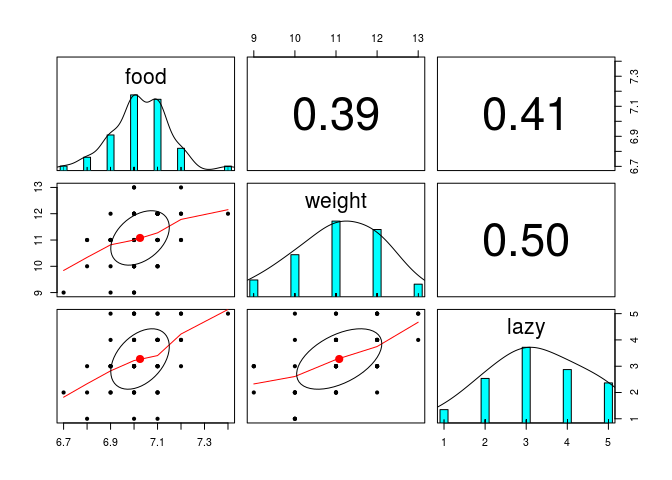

```r
cat_dat %>%
  select(-id) %>% #select all EXCEPT id
  pairs.panels()
```

## STEP 4: CREATING OUR MEDIATION MODEL

*hint, copy & paste from thirst_dat example*

```r
mod1 <- '# a path IV -> Mediator
         weight ~ a * food

         # b path  Mediator -> DV
         lazy ~ b * weight

         # c prime path  IV -> DV
         lazy ~ cp * food

         # indirect and total effects
         ab := a * b
         total := cp + ab'
```

Next, set random seed so results can be reproduced

```r
set.seed(1234)
```

## STEP 5: RUNNING SEM

Fit model. You must specify bootstrapping in the `sem()` function

Normally I run 10000, but it takes time.To be time efficient, we will only run 1000 today

*hint, use* `sem()`

```r
csem1 <- sem(mod1, data = cat_dat, se = "bootstrap", bootstrap = 1000)
```

## STEP 6: SUMMARIZE MODEL

`standardized = TRUE` adds standardized estimate to the model output

*hint, use* `summary()` *& set* `standardized = TRUE`

```r
summary(csem1, standardized = TRUE)
```

```
## lavaan 0.6-7 ended normally after 23 iterations
##
##   Estimator                                         ML
##   Optimization method                           NLMINB
##   Number of free parameters                          5
##
##   Number of observations                            51
##
## Model Test User Model:
##
##   Test statistic                                 0.000
##   Degrees of freedom                                 0
##
## Parameter Estimates:
##
##   Standard errors                            Bootstrap
##   Number of requested bootstrap draws             1000
##   Number of successful bootstrap draws            1000
##
## Regressions:
##                    Estimate  Std.Err  z-value  P(>|z|)   Std.lv  Std.all
##   weight ~
##     food       (a)    3.216    0.884    3.637    0.000    3.216    0.387
##   lazy ~
##     weight     (b)    0.448    0.151    2.968    0.003    0.448    0.403
##     food      (cp)    2.349    1.122    2.093    0.036    2.349    0.255
##
## Variances:
##                    Estimate  Std.Err  z-value  P(>|z|)   Std.lv  Std.all
##    .weight            0.895    0.156    5.738    0.000    0.895    0.850
##    .lazy              0.899    0.158    5.690    0.000    0.899    0.693
##
## Defined Parameters:
##                    Estimate  Std.Err  z-value  P(>|z|)   Std.lv  Std.all
##     ab                1.440    0.568    2.534    0.011    1.440    0.156
##     total             3.788    0.986    3.844    0.000    3.788    0.411
```

Print all model parameters

*hint: use* `parameterestimates()`

```r
parameterestimates(csem1, boot.ci.type = "bca.simple", standardized = TRUE) %>%
  kable() %>%
  scroll_box(width = 100)
```

| lhs | op | rhs | label | est | se | z | pvalue | ci.lower | ci.upper | std.lv | std.all | std.nox |
| --- | --- | --- | --- | --- | --- | --- | --- | --- | --- | --- | --- | --- |
| weight | ~ | food | a | 3.2155477 | 0.8841289 | 3.636967 | 0.0002759 | 1.4873694 | 5.0374219 | 3.2155477 | 0.3868080 | 3.1340680 |
| lazy | ~ | weight | b | 0.4476780 | 0.1508224 | 2.968247 | 0.0029950 | 0.1372541 | 0.7273299 | 0.4476780 | 0.4032830 | 0.4032830 |
| lazy | ~ | food | cp | 2.3489606 | 1.1221495 | 2.093269 | 0.0363252 | -0.2339521 | 4.3660782 | 2.3489606 | 0.2545426 | 2.0624022 |
| weight | ~~ | weight |  | 0.8951708 | 0.1560039 | 5.738132 | 0.0000000 | 0.6483533 | 1.2705658 | 0.8951708 | 0.8503796 | 0.8503796 |
| lazy | ~~ | lazy |  | 0.8991588 | 0.1580196 | 5.690172 | 0.0000000 | 0.6552198 | 1.3441618 | 0.8991588 | 0.6931571 | 0.6931571 |
| food | ~~ | food |  | 0.0152326 | 0.0000000 | NA | NA | 0.0152326 | 0.0152326 | 0.0152326 | 1.0000000 | 0.0152326 |
| ab | := | a*b | ab | 1.4395300 | 0.5680388 | 2.534211 | 0.0112701 | 0.5082945 | 2.8795220 | 1.4395300 | 0.1559931 | 1.2639165 |
| total | := | cp+ab | total | 3.7884906 | 0.9855143 | 3.844176 | 0.0001210 | 1.2334699 | 5.5042977 | 3.7884906 | 0.4105357 | 3.3263187 |

## STEP 7: INTERPRET

### INTERPRET a

Every 1 unit increase in food intake was associated with an a = 3.216 (SE 0.884) increase in weight units.

### INTERPRET b

Adjusting for food, every 1 unit (lb) increase in wegiht was associated with being b = 0.448 (SE = 0.151) more lazy.

### DESCRIBE PATH

Increased in food consumption were associated with increased in laziness INDIRECTLY through increases in weight.

### DESCRIBE ab

Specifically, for every a = 3.216 unit increase in the association between food intake and weight, there was an ab = 1.440 (SE 0.568) increase in how lazy the was (INDIRECT EFFECT).

### DESCRIBE CI

Importantly, a bias-corrected bootstrapped confidence interval with 1,000 samples was above zero, 95% CI [0.508, 2.88].

### DESCRIBE C’

Lastly, a partial mediation showed that food intake was associated with cat laziness independent of its association with weight, c’ = 2.349 (SE 1.122, p = 0.04).

## PSYCH PACKAGE

Test same model using psych package

*hint, use* `mediate()` *from psych package*

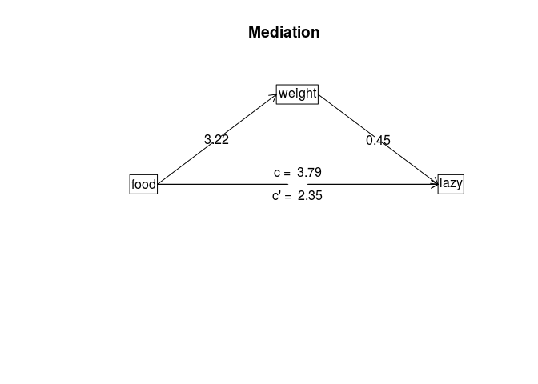

```
##
## Mediation/Moderation Analysis
## Call: mediate(y = "lazy", x = "food", m = "weight", data = ., n.iter = 1000)
##
## The DV (Y) was  lazy . The IV (X) was  food . The mediating variable(s) =  weight .
##
## Total effect(c) of  food  on  lazy  =  3.79   S.E. =  1.2  t  =  3.15  df=  49   with p =  0.0028
## Direct effect (c') of  food  on  lazy  removing  weight  =  2.35   S.E. =  1.2  t  =  1.95  df=  48   with p =  0.057
## Indirect effect (ab) of  food  on  lazy  through  weight   =  1.44
## Mean bootstrapped indirect effect =  1.41  with standard error =  0.57  Lower CI =  0.45    Upper CI =  2.61
## R = 0.55 R2 = 0.31   F = 10.62 on 2 and 48 DF   p-value:  1.8e-05
##
##  To see the longer output, specify short = FALSE in the print statement or ask for the summary
```

```r
cat_dat %>%
  mediate(y = "lazy", x = "food", m = "weight", n.iter = 1000) %>%
  print(short = TRUE)
```